## Set up

```r
library(org.Mm.eg.db)
library(AnnotationDbi)
library(EnhancedVolcano)
library(enrichR)
library(DESeq2)
library(ggplot2); theme_set(theme_bw(base_size = 16)) # for making plots
library(magrittr) # for "pipe"-like coding in R
library(clusterProfiler)
library(cowplot)
```

# Introduction

The correct reading and translation of the genetic code into functional proteins is essential for cell fate. Nonsense-mediated mRNA decay (NMD) is a cellular surveillance mechanism that controls the quality of mRNA by degrading transcripts (Lykke-Andersen & Jensen 2015). By phosphorylating UPF1 and UPF2, SMG1 promotes the recruitment of SMG6 endonuclease or SMG5/SMG7-mediated exonuclease for RNA degradation (Lykke-Andersen & Jensen 2015).

Deficiency in NMD can cause the accumulation of deleterious mRNA products, leading to the production of mutated malfunctional or functional proteins that can result in tissue dysfunction or pathogenesis (Han et al. 2018). Knocking out NMD genes such as Upf1, Upf2, or Smg1 leads to embryonic lethality, indicating the vital role NMD plays in early development (Medghalchi et al. 2001; Weischenfeldt et al. 2008; McIlwain et al. 2010). Previous research has shown that the complete deletion of Smg6 in mouse germline results in early embryonic lethality by blocking the differentiation of embryonic stem cells into germ layers (Li et al. 2015). Additionally, SMG6 is required for the production of induced pluripotent stem cells from somatic cells, suggesting that SMG6-mediated NMD is a critical regulator of cell fate change and controls differentiation and development (Li et al. 2015).

NMD factors are implicated in several neurological disorders in humans (Jaffrey & Wilkinson 2018). Despite these findings, the precise molecular mechanism underlying these processes remains largely unknown.To elucidate the function of SMG6 in neurogenesis during brain development, Guerra et al. (2021) inactivated Smg6 in various neural progenitor cells. They found that SMG6 is more critical for the cell fate determination of interneuron progenitors in the ganglionic eminence (GE) compared to cortical neuroprogenitor cells (NPCs). To investigate the genetic effect of SMG6 knockout, I analyzed their RNAseq data of mouse neuroprogenitor cells (NPCs) under three conditions (control, control+4OHT, Smg6-iKO) and performed differential gene expression analysis and pathway enrichment.

SMG6 is an endonuclease that mediates mRNA decay by NMD, thereby regulating gene expression and controlling mRNA quality. Therefore, I hypothesized that SMG6 KO cells will show upregulation of other genes involved in NMD such as UPF1 as compensation and we will see enrichment for NMD pathways of differentially expressed genes.

# GitHub Repository

The GitHub Repository of this project can be found [here](https://github.com/Jennie421/SMG6_RNA_SEQ). You can find all scripts for processing raw sequencing data (under `scripts`) and a detailed tutorial (`tutorial.Rmd` under `report_and_tutorial`) for executing the commands and downstream analysis in R.

# Results

Load datasets generated from analysis as demonstrated in `tutorial.Rmd`.

```r
load("key_datasets/DESeq.ds.Rdata")
load("key_datasets/DESeq.rlog.Rdata")
load("key_datasets/DEG.results.sorted.Rdata")
```

SMG6-iKO is set as reference level.

```r
DEG.res.sorted = res.ctl4oht.smg6.sorted
```

## PCA plot of the samples

The samples do not cluster by groups.

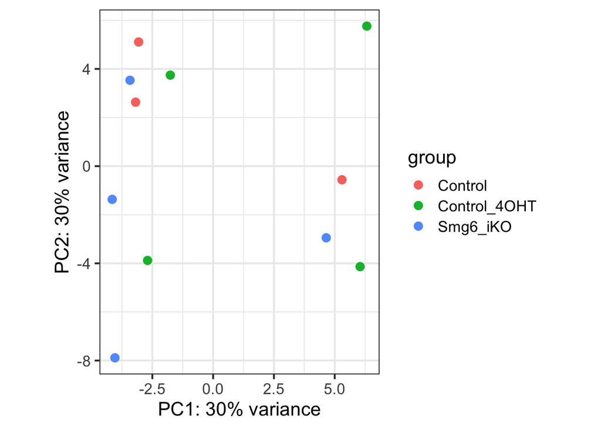

```r
plotPCA(DESeq.rlog, intgroup=c("condition"))
```

## IGV gene coverage

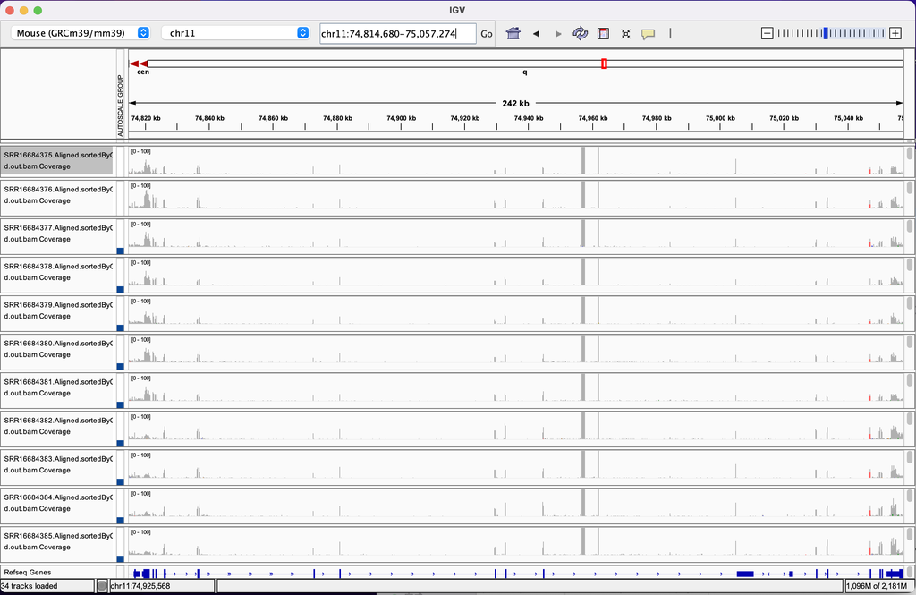

IGV gene coverage

## Import Mm database

```r
mm <- org.Mm.eg.db
```

## Compare SMG6 gene count across groups

The comparison of SMG6 gene counts across groups implies unsuccessful knockout of SMG6 gene since the SMG6 expression level of the KO group is not much lower than the control groups. This gene count is consistent with the authors’ gene counts, suggesting that the knockout is truly not evident.

```r
# get the ensemble ID for SMG6
AnnotationDbi::select(mm, keys="Smg6",keytype="SYMBOL", columns="ENSEMBL")
```

| SYMBOL | ENSEMBL |
| --- | --- |
| Smg6 | ENSMUSG00000038290 |

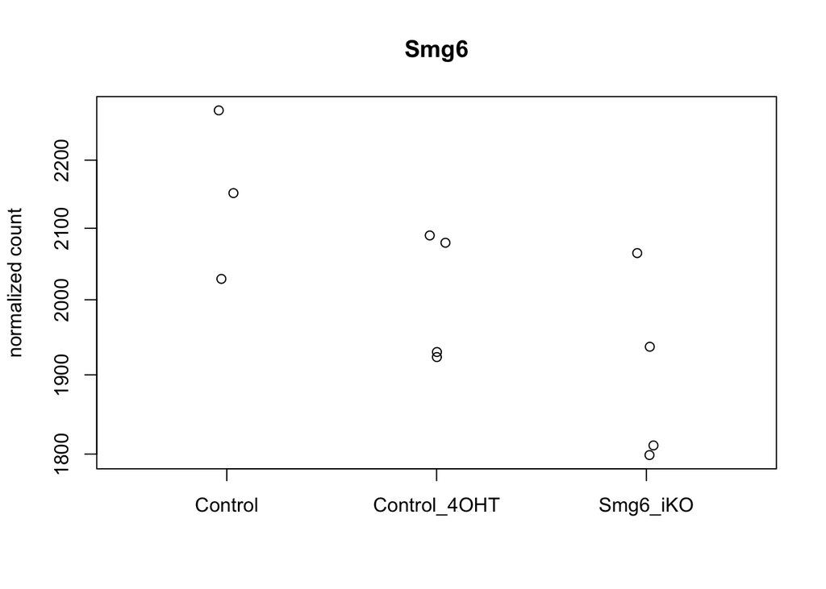

```r
plotCounts(DESeq.ds, gene="ENSMUSG00000038290", normalized=TRUE, xlab="", main="Smg6")
```

Authors’ feature counts for SMG6 for each mice is shown below. Similar to the gene counts I aquired, there is not a big difference in SMG6 expression level between KO and control groups.

```bash
grep "ENSMUSG00000038290" *.txt | cut -f 7
2003
2483
1942
1787
1879
2238
1885
2144
1698
2000
2133
```

## Annotate genes by names

```r
annot.DGE <- AnnotationDbi::select(mm, keys=rownames(DEG.res.sorted),
                    keytype="ENSEMBL", columns="SYMBOL")
DEG.res.sorted$ENSEMBL <- rownames(DEG.res.sorted)
DEG.res.sorted.df <- as.data.frame(DEG.res.sorted)
DEG.res.sorted.df <- merge(x = DEG.res.sorted.df, y = annot.DGE, by= "ENSEMBL", all.x=TRUE)
head(DEG.res.sorted.df)
```

|  | ENSEMBL | baseMean | log2FoldChange | lfcSE | stat | pvalue | padj | SYMBOL |
| --- | --- | --- | --- | --- | --- | --- | --- | --- |
| 1 | ENSMUSG00000000001 | 7595.671059 | -0.1394207 | 0.06397262 | -2.1793810 | 2.930338e-02 | 0.1756142386 | Gnai3 |
| 2 | ENSMUSG00000000028 | 896.567618 | -0.3725306 | 0.08332300 | -4.4709219 | 7.788312e-06 | 0.0005323605 | Cdc45 |
| 3 | ENSMUSG00000000031 | 7849.051921 | -0.1291496 | 0.18088657 | -0.7139809 | 4.752390e-01 | 0.7544433719 | H19 |
| 4 | ENSMUSG00000000037 | 336.287419 | -0.1475878 | 0.10965035 | -1.3459859 | 1.783071e-01 | 0.4737527981 | Scml2 |
| 5 | ENSMUSG00000000049 | 1.920215 | 0.6248957 | 0.99658946 | 0.6270343 | 5.306368e-01 | NA | Apoh |
| 6 | ENSMUSG00000000056 | 4243.984581 | -0.1768001 | 0.08916032 | -1.9829463 | 4.737343e-02 | 0.2306678322 | Narf |

## Volcano plot

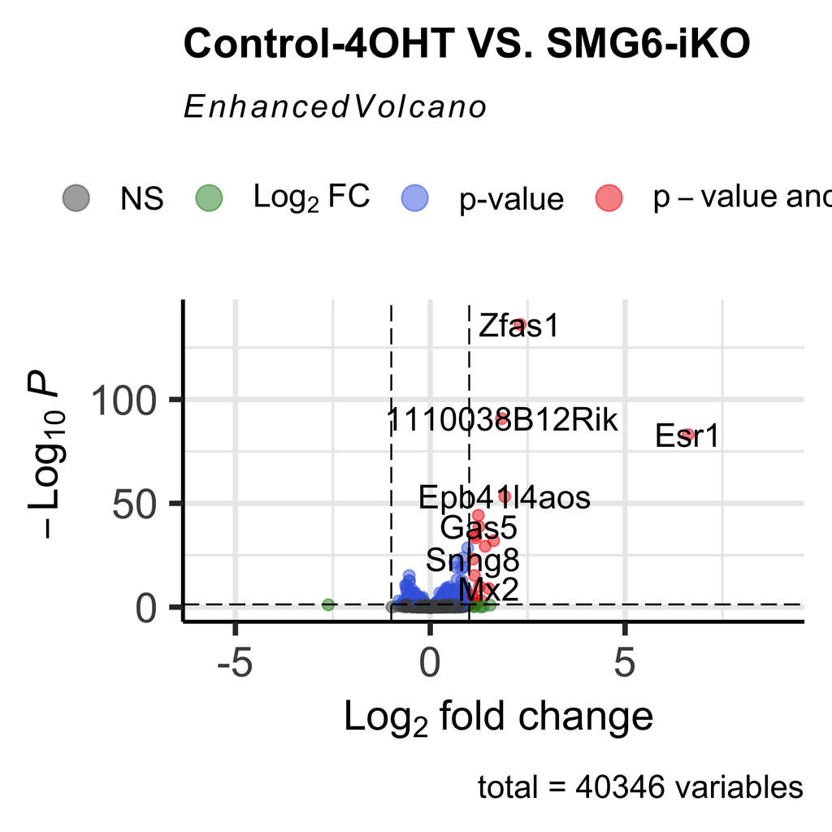

```r
vp1 <- EnhancedVolcano(DEG.res.sorted.df,
                      lab=DEG.res.sorted.df$SYMBOL,
                      x='log2FoldChange', y='padj',
                      pCutoff=0.05,
                      title="Control-4OHT VS. SMG6-iKO")
print(vp1)
```

## Filter for significant genes

```r
DEG.res.sorted.df.sig <- subset(DEG.res.sorted.df, (abs(DEG.res.sorted.df$log2FoldChange) > 0.2 & DEG.res.sorted.df$padj < 0.05)) %>% `[`(order(.$padj),)
# rearrange the columns
DEG.res.sorted.df.sig <- DEG.res.sorted.df.sig[, c(1, 8, 7, 6, 3, 2, 4, 5)]
head(DEG.res.sorted.df.sig, 50)
```

|  | ENSEMBL | SYMBOL | padj | pvalue | log2FoldChange | baseMean | lfcSE | stat |
| --- | --- | --- | --- | --- | --- | --- | --- | --- |
| 18786 | ENSMUSG00000074578 | Zfas1 | 7.253688e-137 | 5.005650e-141 | 2.3072762 | 5083.55932 | 0.09126066 | 25.282266 |
| 24997 | ENSMUSG00000092203 | 1110038B12Rik | 1.625266e-91 | 2.243139e-95 | 1.8302307 | 4249.16706 | 0.08832763 | 20.720929 |
| 2086 | ENSMUSG00000019768 | Esr1 | 8.843759e-84 | 1.830880e-87 | 6.6207572 | 320.31560 | 0.33396888 | 19.824473 |
| 23829 | ENSMUSG00000087590 | Epb41l4aos | 5.238950e-54 | 1.446125e-57 | 1.9136373 | 1520.61832 | 0.11965998 | 15.992291 |
| 26724 | ENSMUSG00000098234 | Snhg6 | 6.220204e-45 | 2.146230e-48 | 1.2328651 | 2505.87590 | 0.08433698 | 14.618323 |
| 14836 | ENSMUSG00000053332 | Gas5 | 1.617027e-39 | 6.695302e-43 | 1.2507421 | 13290.06396 | 0.09109427 | 13.730195 |
| 26364 | ENSMUSG00000097743 | Gm16973 | 2.129784e-35 | 1.028810e-38 | 1.1669422 | 414.02007 | 0.08967343 | 13.013243 |
| 31743 | ENSMUSG00000108414 | Snhg1 | 4.143936e-34 | 2.287729e-37 | 1.1655679 | 4124.20420 | 0.09124460 | 12.774102 |
| 23379 | ENSMUSG00000086841 | 2410006H16Rik | 9.528647e-33 | 5.918006e-36 | 1.6273484 | 7314.34015 | 0.12999600 | 12.518449 |
| 23067 | ENSMUSG00000086290 | Snhg12 | 4.987894e-30 | 3.442063e-33 | 1.4096198 | 2308.70967 | 0.11744263 | 12.002624 |

[output cut: 40 more lines]

The top hits are consistent with the ones shown in the Figure.6a of the publication.

Note that the authors set the cutoff for “log2FoldChange” as 0.2, which means many genes have small effect sizes. If set the cutoff at 1, only 19 genes are considered as significantly unregulated.

## Pathway enrichment

```r
# Load pathway databases
dbs <- listEnrichrDbs()
```

### NMD pathway

gmt file is downloaded from [GSEA mouse gene set NMD](https://www.gsea-msigdb.org/gsea/msigdb/mouse/geneset/GOBP_NUCLEAR_TRANSCRIBED_MRNA_CATABOLIC_PROCESS_NONSENSE_MEDIATED_DECAY.html?keywords=decay)

```r
gmt_df <- read.gmt("GOBP_NUCLEAR_TRANSCRIBED_MRNA_CATABOLIC_PROCESS_NONSENSE_MEDIATED_DECAY.v2023.1.Mm.gmt")
annot.gmt <- AnnotationDbi::select(mm, keys=gmt_df$gene, keytype="SYMBOL", columns="ENSEMBL", multiVals="first")
annot.gmt <- annot.gmt[!duplicated(annot.gmt$SYMBOL), ]
gmt_df$gene <- annot.gmt$ENSEMBL

# rank genes by log2FoldChange
gene_list = DEG.res.sorted.df$log2FoldChange
names(gene_list) <- DEG.res.sorted.df$ENSEMBL
gene_list<- sort(gene_list, decreasing = TRUE)

gse.nmdset <- GSEA(gene_list, TERM2GENE = gmt_df, pvalueCutoff = 1)
```

```
## preparing geneSet collections...
```

```
## GSEA analysis...
```

```
## leading edge analysis...
```

```
## done...
```

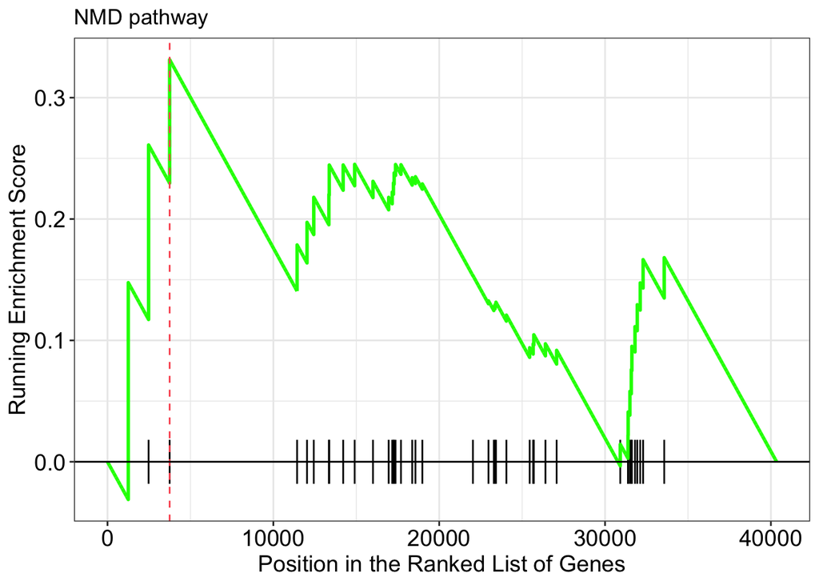

```r
gseaplot(gse.nmdset, geneSetID = 1, by = "runningScore", title="NMD pathway")
```

The result shows that the DE genes are not enriched for the NMD pathway. Thus, my hypothesis that SMG6 knockout will affect the NMD pathway was not supported by the result.

### KEGG pathway enrichment

```r
sig_DEGs <- subset(DEG.res.sorted.df.sig, padj < 0.05, abs(log2FoldChange)>0.2)
sig_upReg_DEGs <- subset(sig_DEGs, log2FoldChange > 0)
sig_downReg_DEGs <- subset(sig_DEGs, log2FoldChange < 0)
```

```r
sig_DEGs <- enrichr(as.vector(na.omit(sig_upReg_DEGs$SYMBOL)), "KEGG_2019_Mouse")
```

```
## Uploading data to Enrichr... Done.
##   Querying KEGG_2019_Mouse... Done.
## Parsing results... Done.
```

```r
upReg_pathways <- enrichr(as.vector(na.omit(sig_upReg_DEGs$SYMBOL)), "KEGG_2019_Mouse")
```

```
## Uploading data to Enrichr... Done.
##   Querying KEGG_2019_Mouse... Done.
## Parsing results... Done.
```

```r
downReg_pathways <- enrichr(as.vector(na.omit(sig_downReg_DEGs$SYMBOL)), "KEGG_2019_Mouse")
```

```
## Uploading data to Enrichr... Done.
##   Querying KEGG_2019_Mouse... Done.
## Parsing results... Done.
```

### KEEG pathway enrichment plots

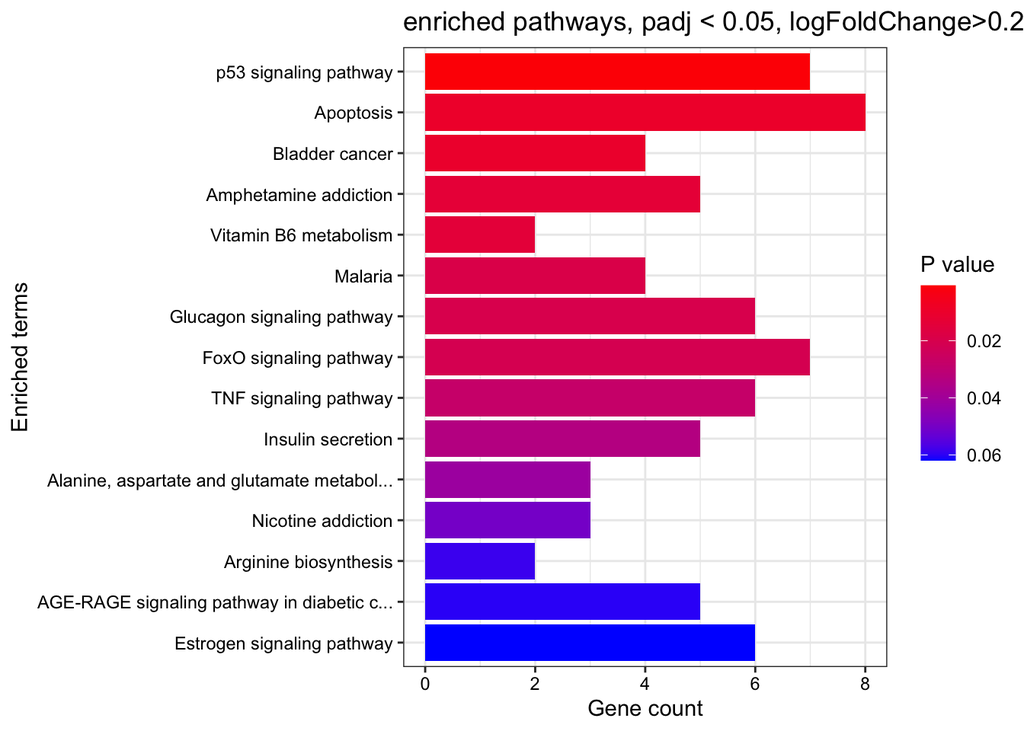

```r
sigDEG_plot <- plotEnrich(sig_DEGs[[1]], showTerms = 15, numChar = 40, y = "Count", orderBy = "Adjusted.P.value", title = "enriched pathways, padj < 0.05, logFoldChange>0.2")

sigDEG_plot
```

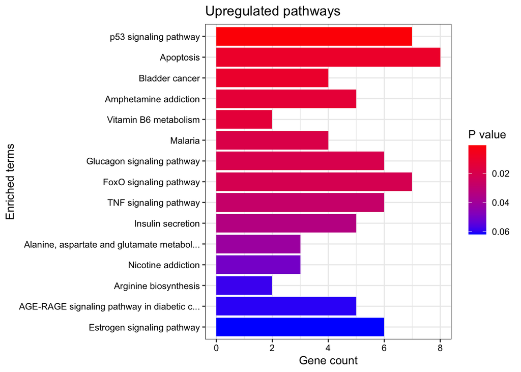

```r
upReg_plot <- plotEnrich(upReg_pathways[[1]], showTerms = 15, numChar = 40, y = "Count", orderBy = "Adjusted.P.value", title = "Upregulated pathways")
upReg_plot
```

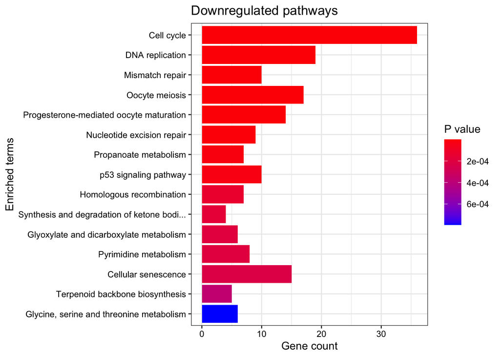

```r
downReg_plot <- plotEnrich(downReg_pathways[[1]], showTerms = 15, numChar = 40, y = "Count", orderBy = "Adjusted.P.value", title = "Downregulated pathways")
downReg_plot
```

The enriched pathways are similar to the ones shown in Figure 6b of the paper.

## Summary of results

The result in the publication was able to be replicated. By using the same cutoff values (`abs(log2FoldChange) > 0.2` and `padj < 0.05`), the list of differential expressed genes and enriched pathways resulted from current analysis are similar to that of the published study. However, the low cutoff indicates that many of the genes identified have small effect sizes. The major reason for this is likely due to incomplete SMG6 knockout. The PCA and SMG6 read counts comparison are both indicative of the unsuccessful knockout. One explanation is that instead of homozygous knockout, only heterozygous knockout was carried out because complete knockout of SMG6 is lethal. However, the limitation in the experiment cannot justify the usage of very low cutoff value. Overall, whether the genetic results shown in the publication are reliable and solid is highly debatable.

Despite the small effect sizes of DEG analysis, my hypothesis is not supported by the results because the DE genes are not enriched for non-sense mediated decay pathways, and genes related to NMD did not appear in the DE gene list.

Future study should aim to generate a KO genotype with decreased level of SMG6 before proceeding to further analysis. With RNA sequencing data from a successful knockout model, we can better validate the function of SMG6 in the central nervous system.

# Methods

## Computational analysis

### 1. Download metadata and raw fastq files

Experiment metadata was downloaded from [NCBI](https://www.ncbi.nlm.nih.gov/Traces/study/?acc=PRJNA776901&o=acc_s%3Aa). The run accession and ftp links from were downloaded from [ENA PRJNA776901](https://www.ebi.ac.uk/ena/browser/view/PRJNA776901). 11 Fastq files are downloaded, which contained the sequencing result from 11 mouse neuroprogenitor cells (NPCs) samples (three controls, four controls with 4-OHT, and four Smg6-iKO with 4-OHT). All samples were sequenced by Illumina HiSeq 2500 with TruSeq stranded protocol library preparation. The read length is 50bp.

### 2. Trim adaptors

`trim-galore` was used to trim adaptor sequences with flags `--gzip` to compress output files and `--illumina` since the data was from illumina platform. `fastqc` and `multiqc` were performed on raw fastq and trimmed fastq files. While the QC showed no obvious difference between raw and trimmed fastq files, the GC content of one of the files was improved after trimming. Thus, the trimmed fastq files were used in the downstream analysis.

### 3. Alignment

Genome assembly and annotation were download from [Ensembl](http://useast.ensembl.org/Mus_musculus/Info/Index). Genome assembly: Mus_musculus.GRCm39.dna.primary_assembly.fa.gz. Annotation: Mus_musculus.GRCm39.109.gtf.gz

STAR index was generated and alignment was performed. `STAR --outSAMtype BAM SortedByCoordinate` was used to generate sorted `bam` files. Quality control of alignment results was perform using `qorts QC`. Flags `--generatePlots` specifies plot generation, and `--singleEnded` and `--stranded` were specified because the RNA-seq protocol was single-ended and stranded.

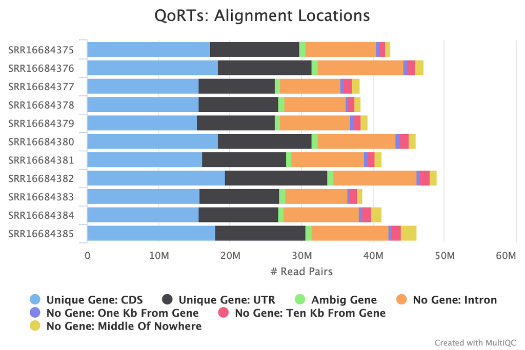

While the majority of reads are mapped to unique genes, a number of reads are mapped to intronic or UTR regions, which suggests usage of ribodepletion protocol.

[figure not shown]

Most reads are mapped to the first strand.

### 4. Feature counts

`featureCounts` was run with parameter `-s 2` because the reads were mapped to the reverse strand.

### 5. Differential expression and pathway enrichment

DESeq2 was used for differential expression analysis and KEGG database is used for pathway enrichment.

## Experiment (Guerra et al. 2021)

RNA Extraction: NPCs were isolated from E13.5 embryo brains (cortices CTX and ganglionic eminences GE) after crossing $Smg6^{flox}$ and $Rosa26-CreER^{T2}$ mice. Kept in neurosphere cultures for 2 days followed by 4-Hydroxytamoxifen (4-OHT) treatment to induce the Smg6 deletion. Total RNA was isolated 6 days after 4-OHT treatment from cells with genotypes.

1. $Smg6^{flox/flox};Rosa26-CreER^{T2}$ without 4-OHT (ctr)
2. $Smg6^{flox/flox}$ treated with 4-OHT (ctr + 4-OHT)
3. $Smg6^{flox/flox};Rosa26-CreER^{T2}$ treated with 4-OHT (Smg6-iKO)

# Discussion

During the project, I encountered an issue with the knockout of SMG6 that was unsuccessful. I noticed that the samples did not cluster by groups effectively on the PCA plot and investigated further by plotting the count of the SMG6 gene in three groups. I found that there was no significant decrease in SMG6 expression in the SMG6-iKO group compared to the controls. This explained the low number of DE genes obtained when using the cutoff of abs(log2FoldChange > 1). To rule out potential errors in parameter use or group name misalignment, I carefully reviewed the scripts and methods used by the authors, but found no obvious mistakes. The consistency between my feature counts for SMG6 and the authors’ feature counts for SMG6 suggested that the issue was with the samples themselves.

# Table

| Dataset | Contains |
| --- | --- |
| feature_counts_strand2 | featureCounts.txt, featureCounts.txt.summary |
| DESeq.ds.Rdata | DESeq object of the dataset |
| DEG.results.sorted.Rdata | Three DEG objects |
| DEG_results_Control_vs_Control4OHT.csv, DEG_results_Control_vs_SMG6iKO.csv, DEG_results_Control4OHT_vs_SMG6iKO.csv | Three csv files of DEG results for pairwise comparison |

# References

Guerra, G. M., May, D., Kroll, T., Koch, P., Groth, M., Wang, Z. Q., Li, T. L., & Grigaravičius, P. (2021). Cell Type-Specific Role of RNA Nuclease SMG6 in Neurogenesis. Cells, 10(12), 3365. https://doi.org/10.3390/cells10123365

Lykke-Andersen, S., & Jensen, T. H. (2015). Nonsense-mediated mRNA decay: an intricate machinery that shapes transcriptomes. Nature reviews. Molecular cell biology, 16(11), 665–677. https://doi.org/10.1038/nrm4063

Han, X., Wei, Y., Wang, H., Wang, F., Ju, Z., & Li, T. (2018). Nonsense-mediated mRNA decay: A ‘nonsense’ pathway makes sense in stem cell biology. Nucleic Acids Research, 46(3), 1038-1051.

Li, T., Shi, Y., Wang, P., Guachalla, L., Sun, B., Joerss, T., . . . Wang, Z. (2015). Smg6/Est1 licenses embryonic stem cell differentiation via nonsense-mediated mRNA decay. The EMBO Journal, 34(12), 1630-1647.

Jaffrey, S., & Wilkinson, M. (2018). Nonsense-mediated RNA decay in the brain: Emerging modulator of neural development and disease. Nature Reviews. Neuroscience, 19(12), 715-728.

Medghalchi, S., Frischmeyer, P., Mendell, J., Kelly, A., Lawler, A., & Dietz, H. (2001). Rent1, a trans-effector of nonsense-mediated mRNA decay, is essential for mammalian embryonic viability. Human Molecular Genetics, 10(2), 99-105.

Weischenfeldt, J., Damgaard, I., Bryder, D., Theilgaard-Mönch, K., Thoren, L., Nielsen, F., . . . Porse, B. (2008). NMD is essential for hematopoietic stem and progenitor cells and for eliminating by-products of programmed DNA rearrangements. Genes & Development, 22(10), 1381-1396.

McIlwain, D., Pan, Q., Reilly, P., Elia, A., McCracken, S., Wakeham, A., . . . Mak, T. (2010). Smg1 is required for embryogenesis and regulates diverse genes via alternative splicing coupled to nonsense-mediated mRNA decay. Proceedings of the National Academy of Sciences - PNAS, 107(27), 12186-12191.